# task18

Deivydas Sinkevičius

2016 m lapkritis 18 d

Jums reikia atlikti paprastą tiesinę regresiją. Prognozuojamas kintamasis y, regresosrius x. Duomenų failas:

https://github.com/1vbutkus/Econometrics1/blob/master/task15/data.csv

**1. Įvertinti tiesinės regresijos modelį yt=β0+β1xt+β2x2t+εt. Pateikti modelio `summary` ir pakomentuoti ką reiškia gauti skaičiai. Kaip interpretuoti gautus rezultatus?**

```r
data <- read.csv("https://raw.githubusercontent.com/1vbutkus/Econometrics1/master/task15/data.csv", header = TRUE)
```

```r
x <- data$x
y <- data$y
mod = lm (y~x+I(x^2))
summary(mod)
```

```
##
## Call:
## lm(formula = y ~ x + I(x^2))
##
## Residuals:
##       Min        1Q    Median        3Q       Max
## -0.046193 -0.013816  0.004572  0.013568  0.043686
##
## Coefficients:
##             Estimate Std. Error t value Pr(>|t|)
## (Intercept) 2.000764   0.002676  747.66   <2e-16 ***
## x           0.120730   0.009876   12.22   <2e-16 ***
## I(x^2)      0.972004   0.019229   50.55   <2e-16 ***
## ---
## Signif. codes:  0 '***' 0.001 '**' 0.01 '*' 0.05 '.' 0.1 ' ' 1
##
## Residual standard error: 0.02047 on 97 degrees of freedom
## Multiple R-squared:  0.9897, Adjusted R-squared:  0.9895
## F-statistic:  4652 on 2 and 97 DF,  p-value: < 2.2e-16
```

Išvestyje matome:

**Iškviestos funkcijos formulė**

**Residuals** kuriame pateikiami minimumo (“Min”), pirmojo kvartilio (“1Q”), medianos (“Median”), trečiojo kvartilio (“3Q”), maksimumo (“Max”) taškai.

**Coefficients**

- Estimate - β0, β1, β2 reikšmės, kai regresijos tiesė aprašoma pavidalu µ(x) = β0 + β1*x + β2*x^2
- Std. Error - Koeficientų įverčių standartinis nuokrypis (kuo mažesnis, tuo geriau. Turėtų būti 2 kartus mažesės nei Estimate reikšmės)
- Pr(>|t|) - tikimybė, kad koeficientas NĖRA reikšmingas. Kuo mažesnis, tuo geriau (mažesnis už nustatytą reikšmingumo lygmenį)
- Significance Stars - *** rodo didelį y priklausomumą nuo x, * - mažą priklausomybę.

**Signif. codes** rodo x ir y priklausomybę su įvairiais reikšmingumo lygmenimis. Blank=bad, Dots=pretty good, Stars=good, More Stars=very good.

**Residual standard error** - Residuals standartinis nuokrypis.

**Multiple R-squared** matuojamas goodness of fit (kuo reikšmė didesnė, tuo geriau, didžiausia galima reikšmė 1)

**F-statistic** parodo, ar modelis, turintis daugiau parametrų tinka labiau už mažiau parametrų turintį modelį.

**2. Padarykite modelio prognozes taškuose (0, 0.3, 0.5).**

```r
newx<-c(0,0.3,0.5) #Susikuriame vektorių newx, kuriame nurodome šiuos taškus
newy = predict(mod, newdata=data.frame(x=newx)) #Randame 'newx' atitinkamą koordinatę 'newy'
newy
```

```
##        1        2        3
## 2.000764 2.124464 2.304130
```

**3. Išbrėžkite kintamųjų sklaidos diagramą kartu su tiesinės regresijos tiese ir naujomis prognozėmis. Grafiką pateikite su pilna legena, kurioje būtų nurodyti visi žymėjimai.**

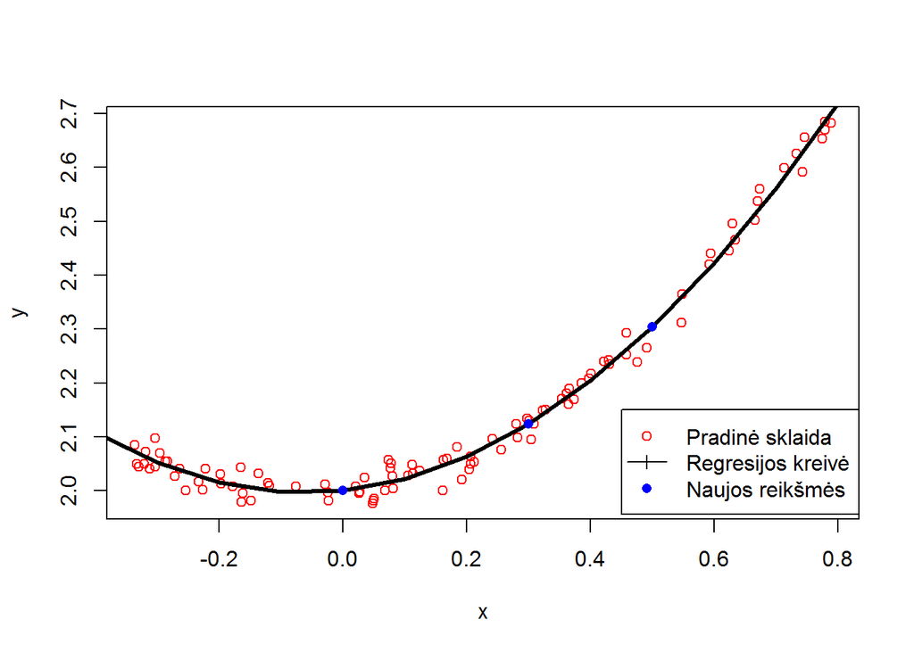

```r
plot(x, y, xlab = "x", ylab = "y", pch = 1, col = '2')  # Nubraižome pirminių duomenų sklaidą
newy2 <- predict(mod, newdata = data.frame(x = seq(-0.4, 0.8, 0.1))) #Susikuriame newy2 tam, kad nubrėžtume regresijos kreivę.
lines(seq(-0.4, 0.8, 0.1), newy2, pch = 3, col = 1, lwd = 3) # Nubrėžiame regresijos kreivę
points(newx, newy, pch = 16, col = 4) # Pažymime įsivestus taškus grafike
legend( 0.45, 2.15, c("Pradinė sklaida", "Regresijos kreivė", "Naujos reikšmės"), lty = c(0, 1, 0), pch = c(1, 3, 16), col = c('2','1','4'))  # Susikuriame legendą
```

**4. Pakomentuokite ar tinkamas šis modelis duotiems duomenims. Ar galite pateikti tobulinimo pasiūlymų?**

Manau, kad šis modelis yra tinkamas duotiems duomenims

Rėmiausi Raigardo darbu, taip pat Mildos darbu: https://github.com/MildaPie/Econometrics1/tree/master/task18